# Statistical analysis 1: linear models, wheel-building and randomization

## Bootstrapping

- basic idea: resample existing data *with replacement*
- *if* data are independent samples, sampling with replacement is like doing a nonparametric “simulation”
- `sample()` can sample with replacement too, but need to sample *entire* data set (maintain relationship between predictor & response variables):
- need to replicate and store values of the estimates (usually `coef()`)
- functions for (1) resampling data, (2) fitting model, (3) extracting coefficients
- tricky if data aren’t independent – *block bootstrapping*
- bootstrap confidence intervals: simplest possibilities are (1) Normal approximation (2) percentile/quantile
- the `boot` package implements many possibilities, but I find it clunky
- as with permutation, bootstrap CI are often similar to classical CIs

## Parametric bootstrapping/posterior predictive simulation

```r
MASS::mvrnorm(n.sim,
              mu=coef(fitted.model),
              Sigma=vcov(fitted.model))
```

or via `arm::sim()`.

- *Example*: what fraction of the values were positive between 1990 and 2000?

```r
nineties <- subset(tdat,Year>=1990 & Year<2000)
nval <- nrow(nineties)
rfun <- function() {
    ss <- arm::sim(lm0,1)  ## get one random value
    vals <- rnorm(nval,mean=ss@coef[1]+ss@coef[2]*nineties$cYear,
                  sd=ss@sigma)
    mean(vals>0)
}
mvals <- rdply(100,rfun())
summary(mvals$V1)
```

```
##    Min. 1st Qu.  Median    Mean 3rd Qu.    Max.
##   0.347   0.432   0.474   0.479   0.526   0.653
```

```r
(obs.val <- mean(nineties$GS.NEE>0,na.rm=TRUE))
```

```
## [1] 0.4328
```

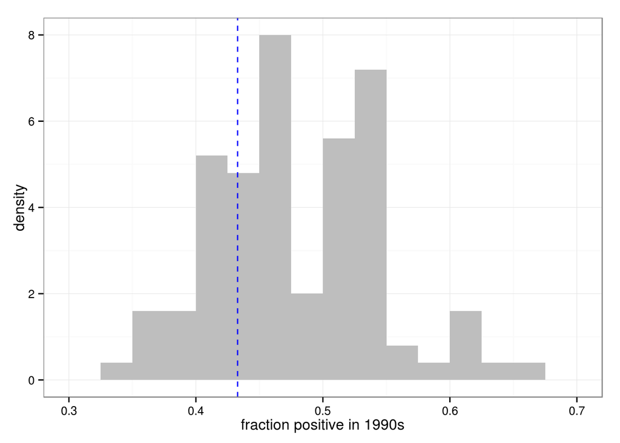

- easy with MCMC approaches
- unfortunately the `simulate()` method only incorporates process/measurement error, while `sim()` only incorporates estimation error

## Method assessment and testing

| **precision** | **accuracy** |
| --- | --- |
| variance | bias |
| coefficient of variation | type I error rate |
| CI width | type I error rate |
| power | *coverage* |
| mean squared error | mean squared error |

- power/performance analysis
  - loop over variable(s) of interest (sample size, effect size, etc.)
    - loop over replicates
      - simulate data
      - analyze data (= fit model)
      - store results (parameter estimates, confidence intervals, $p$ value …)
  - analyze results
- *violin plot* (check for bias):

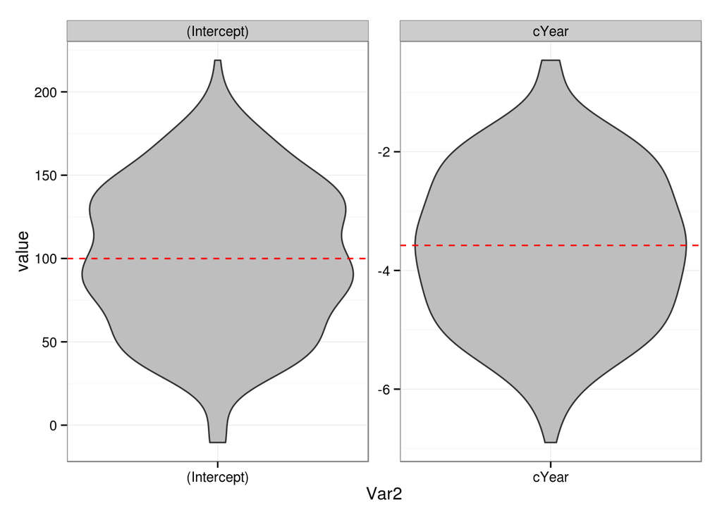

- *caterpillar plot* (check for coverage):

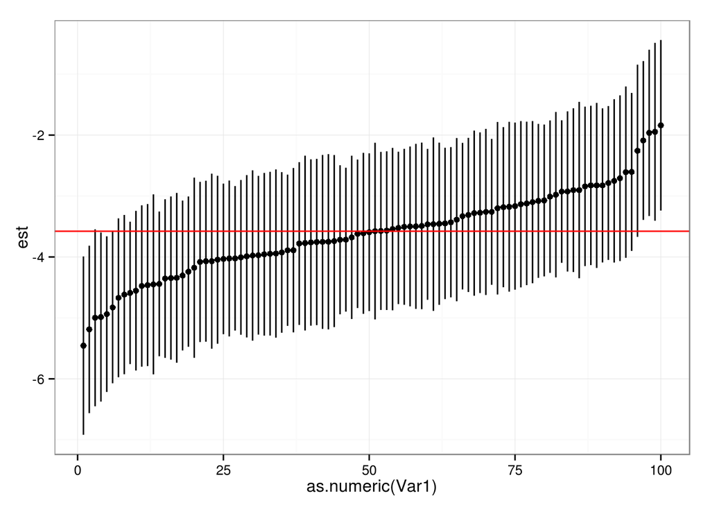

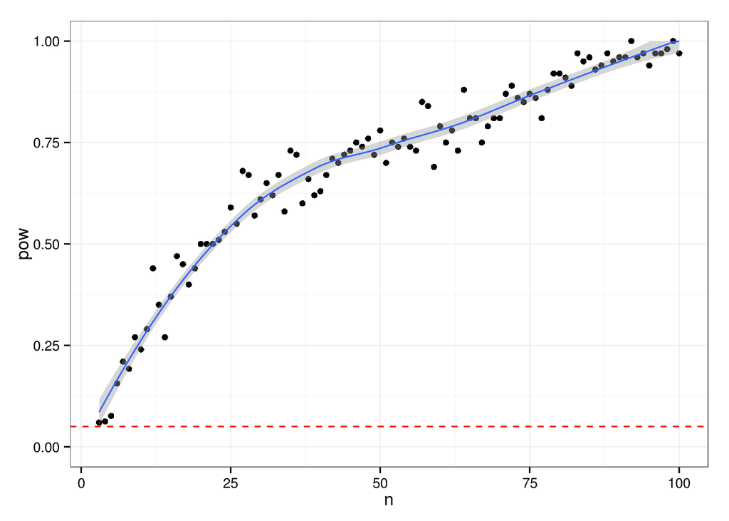

## Tips for simulation studies

- use `try()` in case things break; e.g. `try(x,silent=TRUE); if (inherits(x,"try-error")) return(NA)`
- set random number seeds! possibly sequentially
- organize factorial experiment results as multi-dimensional arrays (with well-named dimensions), with “replicate” and “output variable” as two of the dimensions
- save everything you think you might need for analysis
- use `apply()` to collapse across dimensions (e.g. to get power, coverage, mean bias, MSE)
- use `reshape2::melt` to get from array to long form data